# Predicting Excessive Enforcement Patterns in Police Behavior After Vehicles Stops in New York

Model Selection and Evaluation - LASSO 2-Wheels

Gianmaria Pizzo

These `.Rmd` files represent the project submission for the course [Statistical Inference and Learning](https://www.unive.it/data/course/521944) by Professor [Cristiano Varin](https://www.unive.it/data/people/5592728) at [Ca’ Foscari University of Venice](https://www.unive.it/) for the year 2025/2026.

# 0) Environment

## 0.1) Packages

```r
requirements <- c(
  "scales", "stringr", "dplyr", "tidyr", "viridis",
  "ggplot2", "patchwork", "pROC", "kableExtra", "glmnet"
)
```

The list only contains packages actually used in this notebook. Now, the loading of all packages should be immediate.

## 0.2) Functions

Here we define the helper functions used throughout model selection and evaluation, kept in one place for reuse across every model fitted below.

### 0.2.1) Data-Split Diagnostics

```r
# ==============================================================================
# 1. Train / Test Split Diagnostics
# ==============================================================================

#' @title Check Train/Test Level Proportions
#'
#' @description Tabulates one variable's level proportions separately in
#' `train` and `test` and reports the discrepancy in percentage points. Used
#' to verify that the stratified split preserved the marginal distribution of
#' key covariates.
#'
#' @param var The column name (present in both `train` and `test`) to tabulate.
#' @param label Human-readable label for the variable, stored in the output.
#'
#' @return A tibble with columns variable, level, train, test, diff_ppt.
check_prop <- function(var, label) {
  # Compute the relative frequency of each level in the training set
  tr <- prop.table(table(train[[var]]))
  # Compute the relative frequency of each level in the test set
  te <- prop.table(table(test[[var]]))
  # Create a summary table comparing train and test proportions
  tibble(
    # Variable levels
    level = names(tr),
    # Proportion in training set
    train = as.numeric(tr),
    # Proportion in test set
    test = as.numeric(te),
    # Difference in % between test and training proportions
    diff_ppt = round((as.numeric(te) - as.numeric(tr)) * 100, 2)
  ) %>%
    # Add descriptive variable name
    mutate(variable = label) %>%
    # Move variable name to first column
    relocate(variable)
}
```

### 0.2.2) Threshold and Confusion-Matrix Helpers

```r
# ==============================================================================
# 2. Threshold Selection and Confusion-Matrix Helpers
# ==============================================================================

#' @title Find the Youden-Optimal Classification Threshold
#'
#' @description Finds the probability threshold on an ROC curve that
#' maximises Youden's J statistic (sensitivity + specificity − 1), used
#' throughout as the single decision threshold for turning predicted
#' probabilities into classes.
#'
#' @param roc_obj A pROC "roc" object, as returned by pROC::roc().
#'
#' @return A numeric scalar, the optimal threshold on the probability scale.
best_thresh <- function(roc_obj) {
  pROC::coords(
    roc_obj, "best", ret = "threshold",
    best.method = "youden", quiet = TRUE
  )$threshold
}


#' @title Tally a Confusion Matrix
#'
#' @description Cross-tabulates actual vs predicted binary class labels.
#'
#' @param actual Integer/numeric vector of 0/1 true labels.
#' @param predicted Integer/numeric vector of 0/1 predicted labels.
#'
#' @return A tibble with columns Actual, Predicted, n (one row per non-empty cell).
conf_tib <- function(actual, predicted) {
  tibble(
    Actual = factor(actual, levels = c(0, 1)),
    Predicted = factor(predicted, levels = c(0, 1))
  ) %>%
    count(Actual, Predicted)
}


#' @title Plot a Confusion-Matrix Heatmap
#'
#' @description Renders conf_tib() output as a 2x2 tile plot with cell counts.
#'
#' @param actual Integer/numeric vector of 0/1 true labels.
#' @param predicted Integer/numeric vector of 0/1 predicted labels.
#' @param title Main title of the plot.
#'
#' @return A ggplot2 object.
plot_cm <- function(actual, predicted, title = "Confusion Matrix") {
  conf_tib(actual, predicted) %>%
    ggplot(aes(Predicted, Actual, fill = n)) +
    geom_tile(colour = "white") +
    geom_text(aes(label = scales::comma(n)), size = 5.5, fontface = "bold") +
    scale_fill_gradient(low = "#e8f4f8", high = "#2c7bb6", guide = "none") +
    scale_x_discrete(labels = c("0" = "No arrest", "1" = "Arrest")) +
    scale_y_discrete(labels = c("0" = "No arrest", "1" = "Arrest")) +
    labs(title = title, x = "Predicted", y = "Actual") +
    theme_minimal(base_size = 12) +
    theme(panel.grid = element_blank())
}


#' @title Compute Threshold-Dependent Classification Metrics
#'
#' @description Computes sensitivity, specificity, balanced accuracy, PPV,
#' and NPV for a fixed set of hard class predictions against the true labels.
#'
#' @param actual Integer/numeric vector of 0/1 true labels.
#' @param predicted Integer/numeric vector of 0/1 predicted labels.
#' @param pos Value in `actual`/`predicted` denoting the positive class.
#'
#' @return A named list with sensitivity, specificity, balanced_acc, ppv, npv.
class_metrics <- function(actual, predicted, pos = 1) {
  tp <- as.numeric(sum(actual == pos & predicted == pos))
  tn <- as.numeric(sum(actual != pos & predicted != pos))
  fp <- as.numeric(sum(actual != pos & predicted == pos))
  fn <- as.numeric(sum(actual == pos & predicted != pos))
  sens <- tp / (tp + fn)
  spec <- tn / (tn + fp)
  list(
    sensitivity = sens,
    specificity = spec,
    balanced_acc = (sens + spec) / 2,
    ppv = tp / (tp + fp),
    npv = tn / (tn + fn)
  )
}


# ==============================================================================
# 3. Probability-Based Evaluation Metrics
# ==============================================================================

#' @title Compute the Full Evaluation-Metrics Tibble for One Model
#'
#' @description Given predicted probabilities and true labels, computes
#' threshold-free metrics (AUC, PR-AUC, log-loss, Brier score) plus
#' threshold-dependent metrics at the Youden-optimal cut-off (sensitivity,
#' specificity, precision, F1, MCC, balanced accuracy). Returns one row per
#' call, so results from multiple models can be row-bound into a comparison
#' table.
#'
#' @param actual Integer/numeric vector of 0/1 true labels.
#' @param prob Numeric vector of predicted P(arrested = 1), same length as `actual`.
#' @param thr Classification threshold selected externally (on the training set),
#' applied here rather than recomputed from `actual`/`prob` to avoid leaking test labels.
#' @param model_name Label stored in the Model column.
#'
#' @return A one-row tibble of rounded metrics (see column names in the body).
compute_metrics <- function(actual, prob, thr, model_name = "Model") {
  valid <- !is.na(actual) & !is.na(prob)
  actual <- actual[valid]
  prob <- prob[valid]

  roc_obj <- pROC::roc(actual, prob, quiet = TRUE)
  auc_val <- as.numeric(pROC::auc(roc_obj))
  pred_cl <- as.integer(prob >= thr)

  # Confusion Matrix Metrics
  tp <- as.numeric(sum(actual == 1 & pred_cl == 1))
  tn <- as.numeric(sum(actual == 0 & pred_cl == 0))
  fp <- as.numeric(sum(actual == 0 & pred_cl == 1))
  fn <- as.numeric(sum(actual == 1 & pred_cl == 0))

  # Confusion Matrix Derived Metrics
  sens <- (
    if ((tp+fn) == 0) NA_real_
    else tp / (tp+fn)
  )
  spec <- (
    if ((tn+fp) == 0) NA_real_
    else tn / (tn+fp)
  )
  prec <- (
    if ((tp+fp) == 0) NA_real_
    else tp / (tp+fp)
  )
  f1 <- (
    if (is.na(prec) || is.na(sens) || (prec+sens) == 0) NA_real_
    else 2 * prec * sens / (prec + sens)
  )

  # MCC
  mcc_den <- sqrt(
    as.numeric(tp+fp) * as.numeric(tp+fn) *
    as.numeric(tn+fp) * as.numeric(tn+fn)
  )
  mcc_val <- (
    if (mcc_den == 0) NA_real_
    else (tp*tn - fp*fn) / mcc_den
  )

  # Logloss
  eps <- 1e-15
  logloss <- -mean(
    actual * log(pmax(prob, eps)) +
    (1-actual) * log(pmax(1-prob, eps))
  )

  # Brier Score
  brier <- mean((prob - actual)^2)

  # PR-AUC via trapezoid rule over pROC coords (pROC has no built-in PR-AUC)
  pr_raw <- pROC::coords(
    roc_obj, "all", ret = c("sensitivity", "precision"),
    transpose = FALSE, drop = FALSE
  )

  names(pr_raw)[names(pr_raw) == "sensitivity"] <- "recall"

  pr_raw <- pr_raw %>%
    filter(!is.nan(precision), !is.na(precision), !is.nan(recall)) %>%
    arrange(recall)

  pr_auc_val <- if (nrow(pr_raw) >= 2)
    sum(diff(pr_raw$recall) * (head(pr_raw$precision, -1) + tail(pr_raw$precision, -1)) / 2)
  else NA_real_

  # Print Metrics
  tibble(
    Model = model_name,
    AUC = round(auc_val, 4),
    PR_AUC = round(pr_auc_val, 4),
    Log_Loss = round(logloss, 4),
    Brier = round(brier, 4),
    Threshold = round(thr, 4),
    Sensitivity = round(sens, 3),
    Specificity = round(spec, 3),
    Precision = round(prec, 3),
    F1 = round(f1, 3),
    MCC = round(mcc_val, 3),
    Bal_Acc = round(
      if (!is.na(sens) && !is.na(spec)) (sens+spec)/2
      else NA_real_, 3
    )
  )
}
```

### 0.2.3) Model Evaluation Plot Functions

```r
# ==============================================================================
# 4. Plots for Single-Model Evaluation
# ==============================================================================

#' @title Plot the ROC Curve for a Single Model
#'
#' @description Plots sensitivity vs specificity across all thresholds, with
#' the AUC annotated on the panel.
#'
#' @param actual Integer/numeric vector of 0/1 true labels.
#' @param prob Numeric vector of predicted P(arrested = 1), same length as `actual`.
#' @param title Main title of the plot.
#'
#' @return A ggplot2 object.
plot_roc_single <- function(actual, prob, title = "ROC Curve") {
  roc_obj <- pROC::roc(actual, prob, quiet = TRUE)
  auc_lbl <- paste0("AUC = ", round(as.numeric(pROC::auc(roc_obj)), 4))
  pROC::ggroc(roc_obj, colour = "#2c7bb6", linewidth = 0.9) +
    geom_abline(slope = 1, intercept = 1, linetype = "dashed", colour = "grey60") +
    annotate("text", x = 0.25, y = 0.06, label = auc_lbl, colour = "#2c7bb6", size = 4) +
    labs(x = "Specificity", y = "Sensitivity", title = title) +
    theme_minimal(base_size = 11) +
    theme(panel.grid.minor = element_blank())
}
```

```r
#' @title Plot the Precision-Recall Curve for a Single Model
#'
#' @description Plots precision vs recall across all thresholds against the
#' no-skill baseline (the class prevalence), with PR-AUC annotated. More
#' informative than the ROC curve under the severe class imbalance here.
#'
#' @param actual Integer/numeric vector of 0/1 true labels.
#' @param prob Numeric vector of predicted P(arrested = 1), same length as `actual`.
#' @param title Main title of the plot.
#'
#' @return A ggplot2 object.
plot_pr_single <- function(actual, prob, title = "Precision-Recall Curve") {
  roc_obj <- pROC::roc(actual, prob, quiet = TRUE)
  pr_raw  <- pROC::coords(roc_obj, "all",
                           ret = c("sensitivity", "precision"),
                           transpose = FALSE, drop = FALSE)
  names(pr_raw)[names(pr_raw) == "sensitivity"] <- "recall"
  pr_df <- pr_raw %>%
    filter(!is.nan(precision), !is.na(precision)) %>% arrange(recall)

  # PR-AUC via trapezoid rule, same approach as in compute_metrics()
  pr_auc_lbl <- if (nrow(pr_df) >= 2) {
    v <- sum(diff(pr_df$recall) *
               (head(pr_df$precision,-1) + tail(pr_df$precision,-1)) / 2)
    paste0("PR-AUC = ", round(v, 4))
  } else "PR-AUC = NA"
  baseline <- mean(actual)
  ggplot(pr_df, aes(x = recall, y = precision)) +
    geom_line(colour = "#d73027", linewidth = 0.9) +
    geom_hline(yintercept = baseline, linetype = "dashed", colour = "grey55") +
    annotate("text", x = 0.02, y = baseline + 0.015,
             label = paste0("No-skill = ", round(baseline, 3)),
             colour = "grey40", size = 3.2, hjust = 0) +
    annotate("text", x = 0.55, y = 0.90, label = pr_auc_lbl,
             colour = "#d73027", size = 4) +
    scale_x_continuous(limits = c(0, 1)) + scale_y_continuous(limits = c(0, 1)) +
    labs(x = "Recall", y = "Precision", title = title) +
    theme_minimal(base_size = 11) + theme(panel.grid.minor = element_blank())
}
```

```r
#' @title Plot the Calibration (Reliability) Curve for a Single Model
#'
#' @description Bins predictions into `n_bins` equal-frequency groups and
#' plots mean predicted probability against observed positive rate per bin,
#' against the perfect-calibration diagonal.
#'
#' @param actual Integer/numeric vector of 0/1 true labels.
#' @param prob Numeric vector of predicted P(arrested = 1), same length as `actual`.
#' @param title Main title of the plot.
#' @param n_bins Number of quantile bins of `prob`.
#'
#' @return A ggplot2 object.
plot_calibration_single <- function(actual, prob, title = "Calibration Plot",
                                    n_bins = 10) {
  # Quantile breaks (not equal-width) so each bin has a comparable sample size
  # despite the predicted probabilities being heavily right-skewed
  brks  <- unique(quantile(prob, seq(0, 1, length.out = n_bins + 1), na.rm = TRUE))
  cal_df <- tibble(actual = actual, prob = prob) %>%
    mutate(bin = cut(prob, breaks = brks, include.lowest = TRUE)) %>%
    filter(!is.na(bin)) %>%
    group_by(bin) %>%
    summarise(mean_pred = mean(prob), mean_obs = mean(actual),
              n = n(), .groups = "drop")
  ggplot(cal_df, aes(x = mean_pred, y = mean_obs)) +
    geom_abline(slope = 1, intercept = 0, linetype = "dashed", colour = "grey55") +
    geom_line(colour = "#2c7bb6", linewidth = 0.8) +
    geom_point(aes(size = n), colour = "#2c7bb6", alpha = 0.85) +
    scale_size_continuous(name = "Count", range = c(2, 9)) +
    scale_x_continuous(labels = scales::percent_format(accuracy = 0.1)) +
    scale_y_continuous(labels = scales::percent_format(accuracy = 0.1)) +
    labs(x = "Mean predicted probability", y = "Observed positive rate",
         title = title,
         caption = "Size ∝ bin count.  Dashed = perfect calibration.") +
    theme_minimal(base_size = 11) +
    theme(legend.position = "bottom", panel.grid.minor = element_blank())
}
```

```r
#' @title Plot the Threshold-Sweep Metrics for a Single Model
#'
#' @description Plots sensitivity, specificity, precision, and F1 as
#' functions of the classification threshold, with the Youden-optimal
#' threshold marked.
#'
#' @param actual Integer/numeric vector of 0/1 true labels.
#' @param prob Numeric vector of predicted P(arrested = 1), same length as `actual`.
#' @param thr Classification threshold selected externally (on the training set).
#' @param title Main title of the plot.
#'
#' @return A ggplot2 object.
plot_threshold_single <- function(actual, prob, thr, title = "Threshold Analysis") {
  roc_obj  <- pROC::roc(actual, prob, quiet = TRUE)
  thr_data <- pROC::coords(roc_obj, "all",
                            ret = c("threshold","sensitivity","specificity","precision"),
                            transpose = FALSE, drop = FALSE) %>%
    filter(is.finite(threshold), threshold >= 0, threshold <= 1) %>%
    mutate(f1 = ifelse(!is.nan(precision) & (precision + sensitivity) > 0,
                       2 * precision * sensitivity / (precision + sensitivity), 0)) %>%
    pivot_longer(c(sensitivity, specificity, precision, f1),
                 names_to = "Metric", values_to = "Value") %>%
    mutate(Metric = recode(Metric,
      sensitivity = "Sensitivity", specificity = "Specificity",
      precision   = "Precision",   f1          = "F1 Score"))
  ggplot(thr_data, aes(x = threshold, y = Value, colour = Metric)) +
    geom_line(linewidth = 0.75, na.rm = TRUE) +
    geom_vline(xintercept = thr, linetype = "dashed",
               colour = "grey35", linewidth = 0.55) +
    annotate("text", x = thr, y = 0.04,
             label = paste0("Train-selected\n", round(thr, 3)),
             hjust = -0.08, size = 3, colour = "grey30") +
    scale_colour_viridis_d(option = "turbo", begin = 0.05, end = 0.92) +
    scale_y_continuous(limits = c(0, 1)) +
    labs(x = "Threshold", y = "Metric value", colour = NULL, title = title,
         caption = "Dashed: threshold selected on the training set") +
    theme_minimal(base_size = 11) +
    theme(legend.position = "bottom", panel.grid.minor = element_blank())
}
```

```r
#' @title Plot the 2x2 Evaluation Panel for a Single Model
#'
#' @description Composes plot_roc_single(), plot_pr_single(),
#' plot_calibration_single(), and plot_threshold_single() into one
#' (ROC | PR) / (Calibration | Threshold) patchwork layout.
#'
#' @param actual Integer/numeric vector of 0/1 true labels.
#' @param prob Numeric vector of predicted P(arrested = 1), same length as `actual`.
#' @param thr Classification threshold selected externally (on the training set).
#' @param model_name Prefixed to each sub-plot's title.
#'
#' @return A patchwork object (composed ggplot2 object).
eval_quad_plot <- function(actual, prob, thr, model_name) {
  p1 <- plot_roc_single(actual, prob,   paste(model_name, "— ROC"))
  p2 <- plot_pr_single(actual, prob,    paste(model_name, "— Precision-Recall"))
  p3 <- plot_calibration_single(actual, prob, paste(model_name, "— Calibration"))
  p4 <- plot_threshold_single(actual, prob, thr, paste(model_name, "— Threshold Analysis"))
  (p1 | p2) / (p3 | p4)
}
```

### 0.2.4) Model-Summary Helpers

```r
# ==============================================================================
# 5. Coefficient Extraction Helpers
# ==============================================================================

#' @title Extract Non-Zero LASSO Coefficients at a Given Lambda
#'
#' @description Extracts the coefficients selected by a cv.glmnet fit at a
#' named lambda (e.g. "lambda.min" or "lambda.1se"), drops the zeroed-out
#' coefficients, and adds the exponentiated odds ratio.
#'
#' @param cv_fit A fitted glmnet::cv.glmnet object.
#' @param s_name Lambda selector passed to coef(cv_fit, s = s_name), typically
#' "lambda.min" or "lambda.1se".
#'
#' @return A tibble with columns feature, estimate (log-odds), OR (odds ratio),
#' sorted by descending |estimate|.
extract_coefs <- function(cv_fit, s_name) {
  cf <- coef(cv_fit, s = s_name)
  tibble(
    feature  = rownames(cf)[-1],
    estimate = as.numeric(cf[-1])
  ) %>%
    filter(estimate != 0) %>%
    arrange(desc(abs(estimate))) %>%
    mutate(OR = round(exp(estimate), 3), estimate = round(estimate, 4))
}
```

# 1) Data Loading and Preparation

```r
vehstop <- read.csv("data/vehiclestops_2_wheels_final.csv")
```

## 1.1) Factor conversion and Reference Levels

We convert all categorical predictors to factors and set interpretable reference levels before any modelling step, ensuring consistency between all downstream model fits and cross-validation folds.

```r
# Ordered weekday levels (ISO order)
wday_levels <- c("Monday", "Tuesday", "Wednesday", "Thursday", "Friday", "Saturday", "Sunday")

# Ordered time bracket levels
tbkt_levels <- c(
  "Late night (0–3)",
  "Early morning (4–7)",
  "Morning commute (8–11)",
  "Midday (12–15)",
  "Afternoon/evening (16–19)",
  "Night (20–23)"
)

# Ordered age-bracket levels
abkt_levels <- c("Under 18", "18–24", "25–34", "35–44", "45–54", "55–64", "65+", "Unknown")

vehstop <- vehstop %>%
  mutate(
    year = factor(year),
    month = factor(month, levels = 1:12),
    weekday = factor(weekday, levels = wday_levels),
    hour = factor(hour, levels = 0:23),
    time_bracket = factor(time_bracket, levels = tbkt_levels),
    area = factor(area),
    boro = factor(boro),
    sex = factor(sex),
    ethnicity = factor(ethnicity),
    age_bracket = factor(age_bracket, levels = abkt_levels)
  )

# Reference levels chosen for interpretable contrasts
vehstop$sex <- relevel(vehstop$sex, ref = "M")
vehstop$ethnicity <- relevel(vehstop$ethnicity, ref = "White")
vehstop$weekday <- relevel(vehstop$weekday, ref = "Monday")
vehstop$time_bracket <- relevel(vehstop$time_bracket, ref = "Morning commute (8–11)")
vehstop$age_bracket <- relevel(vehstop$age_bracket, ref = "25–34")

rm(wday_levels, tbkt_levels, abkt_levels)
```

## 1.2) Stratified Train / Test Split

For the train/test split, a **stratified sampling approach** is used to ensure that the training and test sets have comparable distributions of the outcome variable (`arrested`) and relevant contextual variables.

This is particularly important because the target variable is imbalanced, with arrested cases representing only a small proportion of all observations. Rather than stratifying only on `arrested`, the code constructs a **joint stratification variable** from `arrested`, `area`, `sex`, `ethnicity`, and `hour` using `interaction()`. Thus, each observation is assigned to a stratum corresponding to a particular combination of these variables.

Formally, the strata can be represented as

$$S_i =
(\text{arrested}_i,\text{area}_i,\text{sex}_i,\text{ethnicity}_i,\text{hour}_i),$$

where $S_i$ denotes the stratum to which observation $i$ belongs. The objective is to sample approximately 80% of observations within each stratum for the training set and retain the remaining 20% for testing:

$$P(i \in \mathcal{D}_{train} \mid S_i=s)
\approx 0.8,
\qquad
P(i \in \mathcal{D}_{test} \mid S_i=s) \approx 0.2.$$

```r
set.seed(2026)

# Joint stratum key; drop = TRUE removes empty combinations
vehstop$.strat <- interaction(
  vehstop$arrested, vehstop$area, vehstop$sex, vehstop$ethnicity, vehstop$hour,
  drop = TRUE
)

train_rows <- vehstop %>%
  dplyr::mutate(.row = row_number()) %>%
  dplyr::group_by(.strat) %>%
  dplyr::slice_sample(prop = 0.8) %>%
  dplyr::pull(.row)

train <- vehstop[ train_rows, ] %>% dplyr::select(-.strat)
test  <- vehstop[-train_rows, ] %>% dplyr::select(-.strat)
vehstop <- vehstop %>% dplyr::select(-.strat)
```

In the code, `group_by(.strat) %>% slice_sample(prop = 0.8)` performs this within-stratum sampling, while the observations not selected for training form the test set. This approach aims to preserve not only the overall prevalence of the outcome,

$$P_{\text{train}}(\text{arrested}=1)
\approx P_{\text{test}}(\text{arrested}=1),$$

but also the composition of the data across geographic, demographic, and temporal characteristics. This is desirable because differences in these characteristics could otherwise introduce an unintended distributional difference between the training and test sets. The temporary `.strat` variable is removed after the split because it is used solely to define the sampling groups and is not intended to be used as a predictor in the subsequent modelling.

Finally, the verification code compares the empirical marginal distributions of `arrested`, `area`, `sex`, and `ethnicity` in the two datasets. For a variable $X$ and level $k$, the proportion in each dataset is calculated as

$$\hat{P}_{train}(X=k)
=
\frac{\sum_{i \in \mathcal{D}_{train}} \mathbb{I}(X_i=k)}
{|\mathcal{D}_{train}|},$$

and analogously for the test set. The difference is then reported in **percentage points**:

$$\Delta_k =
100\left[
\hat{P}_{test}(X=k)
-
\hat{P}_{train}(X=k)
\right].$$

Small values of $\Delta_k$ indicate that the corresponding characteristic is similarly represented in the two datasets. The final summary additionally compares the number of observations and the proportion of arrested cases in the training and test sets, providing a direct check that the intended approximately 80/20 split and the class distribution have been maintained.

```r
bind_rows(
  check_prop("arrested", "arrested"),
  check_prop("area", "area"),
  check_prop("sex", "sex"),
  check_prop("ethnicity", "ethnicity")
) %>%
  kbl(
    digits = 4,
    caption = "Proportion of each level in train vs test (diff in percentage points)",
    col.names = c("Variable", "Level", "Train", "Test", "Δ (ppt)")
  ) %>%
  kable_styling(bootstrap_options = c("striped", "hover", "condensed"), full_width = FALSE) %>%
  collapse_rows(columns = 1, valign = "top")
```

Proportion of each level in train vs test (diff in percentage points)

| Variable | Level | Train | Test | Δ (ppt) |
| --- | --- | --- | --- | --- |
| arrested | 0 | 0.9462 | 0.9370 | -0.92 |
|  | 1 | 0.0538 | 0.0630 | 0.92 |
| area | Bronx | 0.1574 | 0.1585 | 0.12 |
|  | Brooklyn | 0.2961 | 0.2939 | -0.22 |
|  | Manhattan | 0.2689 | 0.2678 | -0.11 |
|  | Queens | 0.2705 | 0.2690 | -0.15 |
|  | Staten Island | 0.0070 | 0.0107 | 0.37 |
| sex | M | 0.9602 | 0.9475 | -1.27 |
|  | F | 0.0352 | 0.0444 | 0.92 |
|  | U | 0.0046 | 0.0081 | 0.35 |
| ethnicity | White | 0.0971 | 0.0995 | 0.24 |
|  | Asian / Pacific Islander | 0.1096 | 0.1104 | 0.07 |
|  | Black | 0.2066 | 0.2060 | -0.06 |
|  | Hispanic | 0.4778 | 0.4699 | -0.78 |
|  | Other | 0.0162 | 0.0188 | 0.26 |
|  | Unknown | 0.0928 | 0.0955 | 0.26 |

```r
cat(sprintf(
  "Training set : %d rows  |  Arrested: %.2f%%\nTest set     : %d rows  |  Arrested: %.2f%%\n",
  nrow(train), 100 * mean(train$arrested),
  nrow(test),  100 * mean(test$arrested)
))
```

```
## Training set : 150691 rows  |  Arrested: 5.38%
## Test set     : 38851 rows  |  Arrested: 6.30%
```

```r
# Remove vehstop for memory purposes
rm(vehstop)
```

# 5) LASSO

**Why did we choose this model?** Given the size of the dataset and the rarity of the target, a penalised logistic regression is a trivial choice:

- It scales linearly in $n$,
- It handles many correlated dummy-encoded predictors, and
- It performs feature selection (derived from the $\ell_1$ penalty).

**Modus Operandi:** In this section we fit a LASSO logistic regression on `arrested` using the reduced predictor set (see below), then we compare the model obtained at $\lambda_{\min}$ against the more parsimonious one at $\lambda_{\text{1se}}$.

## 5.1) Assumptions and Setup

**LASSO (Least Absolute Shrinkage and Selection Operator)** is a regularization method that extends logistic regression by adding a penalty on the absolute size of the model coefficients.

In binary classification, it is particularly useful when there are many potentially relevant predictors and we want to identify a smaller set of variables associated with the probability of the positive outcome.

For a binary target $Y \in \{0,1\}$, LASSO logistic regression models

$$P(Y=1\mid X)=\frac{1}{1+\exp(-\eta)},$$

where

$$\eta=\beta_0+\beta_1X_1+\cdots+\beta_pX_p$$

Instead of simply maximizing the logistic likelihood, LASSO minimizes the penalized negative log-likelihood:

$$\hat{\beta} = \arg\min_{\beta} \left\{
-\ell(\beta) + \lambda\sum_{j=1}^{p}|\beta_j| \right\}$$

Here, $\lambda \geq 0$ controls the strength of regularization.

> In other words, this model penalises the sum of absolute coefficient values ($\ell_1$ penalty), which shrinks small effects to exactly zero and performs implicit variable selection.

We had to exclude `age` as a predictor, since we had missing values that we labeled as `Unknown` in `age_bracket`. Therefore, this is the final formulation of the model

```r
f_final <- arrested ~ year + month + weekday + hour + boro + sex + ethnicity + age_bracket
```

### 5.1.1) Model Matrix

Unlike `glm()`, `glmnet()` does not accept a formula and factor predictors directly: it requires a numeric design matrix, so every categorical predictor must be dummy-encoded first via `model.matrix()` (see also section 1.1).

Then, the intercept column produced by `model.matrix()` is dropped (`[, -1]`) because `glmnet` fits its own unpenalised intercept internally.

Standardisation of the columns before penalisation is handled automatically by `glmnet` (`standardize = TRUE` is the default), so no manual scaling is needed here.

```r
mm_train <- model.frame(f_final, data = train, na.action = na.omit)
X_train <- model.matrix(f_final, data = mm_train)[, -1]
y_train <- mm_train$arrested

mm_test <- model.frame(f_final, data = test, na.action = na.omit)
X_test <- model.matrix(f_final, data = mm_test)[, -1]
y_test <- mm_test$arrested

cat("Training matrix:", nrow(X_train), "×", ncol(X_train), "\n")
```

```
## Training matrix: 150691 × 63
```

```r
cat("Test matrix :", nrow(X_test),  "×", ncol(X_test),  "\n")
```

```
## Test matrix : 38851 × 63
```

## 5.2) Hyperparameter Tuning and Model Fit — Cross-Validated Lambda

The regularization parameter is typically selected using cross-validation. With an imbalanced binary outcome, it is important that the cross-validation folds preserve approximately the same proportion of positive cases. Unfortunately, we did not have enough time to create a more precise CV function to take into account proportions in between folds.

```r
set.seed(2026)
cv_lasso <- cv.glmnet(
  X_train, y_train,
  family = "binomial",
  alpha = 1,
  nfolds = 5,
  type.measure = "auc"
)

cat(sprintf(
  "λ.min  = %.6f  (CV AUC = %.4f, SE = %.6f)\nλ.1se  = %.6f  (CV AUC = %.4f, SE = %.6f)\n",
  cv_lasso$lambda.min,
  max(cv_lasso$cvm),
  cv_lasso$cvsd[cv_lasso$lambda == cv_lasso$lambda.min],
  cv_lasso$lambda.1se,
  cv_lasso$cvm[cv_lasso$lambda == cv_lasso$lambda.1se],
  cv_lasso$cvsd[cv_lasso$lambda == cv_lasso$lambda.1se]
))
```

```
## λ.min  = 0.000053  (CV AUC = 0.7394, SE = 0.002211)
## λ.1se  = 0.000711  (CV AUC = 0.7373, SE = 0.002265)
```

```r
coef_min <- extract_coefs(cv_lasso, "lambda.min")
coef_1se <- extract_coefs(cv_lasso, "lambda.1se")

cat("Non-zero coefficients at λ.min:", nrow(coef_min), "\n")
```

```
## Non-zero coefficients at λ.min: 62
```

```r
cat("Non-zero coefficients at λ.1se:", nrow(coef_1se), "\n")
```

```
## Non-zero coefficients at λ.1se: 53
```

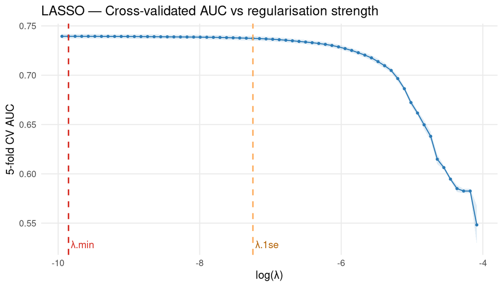

```r
# Replicate the cv.glmnet plot in ggplot2
cv_df <- tibble(
  log_lambda = log(cv_lasso$lambda),
  cvm = cv_lasso$cvm,
  cvup = cv_lasso$cvup,
  cvlo = cv_lasso$cvlo,
  nzero = cv_lasso$nzero,
  cvsd = cv_lasso$cvsd
)

ggplot(cv_df, aes(x = log_lambda, y = cvm)) +
  geom_ribbon(aes(ymin = cvlo, ymax = cvup), alpha = 0.15, fill = "#2c7bb6") +
  geom_line(colour = "#2c7bb6") +
  geom_point(size = 0.8, colour = "#2c7bb6") +
  geom_vline(xintercept = log(cv_lasso$lambda.min), linetype = "dashed",
             colour = "#d73027", linewidth = 0.7) +
  geom_vline(xintercept = log(cv_lasso$lambda.1se), linetype = "dashed",
             colour = "#fdae61", linewidth = 0.7) +
  annotate("text", x = log(cv_lasso$lambda.min), y = min(cv_df$cvlo),
           label = "λ.min", colour = "#d73027", hjust = -0.1, size = 3.5) +
  annotate("text", x = log(cv_lasso$lambda.1se), y = min(cv_df$cvlo),
           label = "λ.1se", colour = "#b36200", hjust = -0.1, size = 3.5) +
  labs(
    x     = "log(λ)",
    y     = "5-fold CV AUC",
    title = "LASSO — Cross-validated AUC vs regularisation strength"
  ) +
  theme_minimal(base_size = 11) +
  theme(panel.grid.minor = element_blank())
```

### 5.2.1) Interpretation of the lambda’s cross-validation curve

At $\lambda_{\text{min}} = 0.000053$

- The model achieves the maximum cross-validated AUC: $\text{AUC} = 0.7394 \pm 0.002211$
- And it retains **62** non-zero coefficients.

At $\lambda_{\text{1se}} = 0.000711$

- The model is much more strongly regularised as it retains only 53 non-zero coefficients,
- But its CV AUC decreases only slightly: $0.7394 \rightarrow 0.7373$

That’s a reduction of only $0.7394 - 0.7373 = 0.0021$ in AUC points at $\lambda_{\text{min}}$.

Meanwhile, the number of coefficients falls from 62 to 53:

$$\frac{62-53}{62}\approx14.5\%$$

So we have approximately a $14.5\%$ reduction in model complexity for a small change in cross-validated predictive performance (AUC).

The SE makes the 1-SE choice even more meaningful. The standard errors are:

$$SE_{\text{min}} = 0.002211 \,\,
\text{and} \,\, SE_{\text{1se}} = 0.002265$$

The difference in AUC is $0.0021$ which is on approximately the same scale as the CV standard error. This supports the interpretation that the *apparent advantage* of $\lambda_{\min}$ is very small relative to the uncertainty in the CV estimate.

**What does this say about the training?** The LASSO model achieves approximately the **same predictive performance with substantially stronger regularisation**. This indicates that stronger regularisation can substantially simplify the model without materially degrading predictive performance. Therefore, $\lambda_{1se}$ is to be preferred as we prioritise interpretability and parsimony are prioritised.

## 5.3) Specific Analysis and Interpretation

### 5.3.1) Coefficient Path

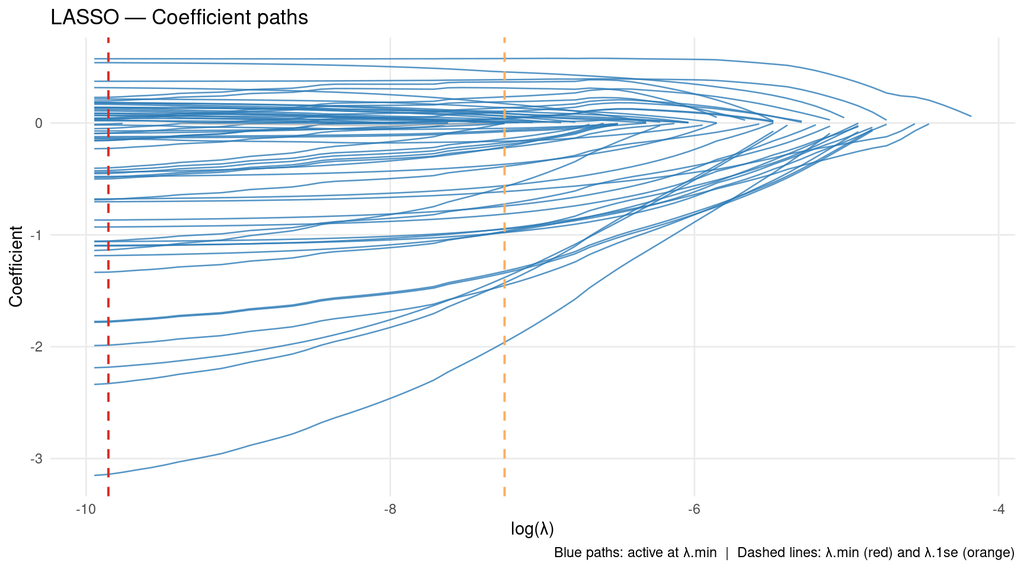

```r
# Tidy the full coefficient path
coef_path <- as.matrix(coef(cv_lasso$glmnet.fit))   # (p+1) × n_lambda
lambdas   <- cv_lasso$glmnet.fit$lambda

path_df <- as.data.frame(t(coef_path[-1, ])) %>%   # drop intercept row
  mutate(log_lambda = log(lambdas)) %>%
  pivot_longer(-log_lambda, names_to = "feature", values_to = "coef") %>%
  filter(coef != 0)

# Only label non-zero at lambda.min for clarity
active_min <- names(which(coef(cv_lasso, s = "lambda.min")[-1, 1] != 0))

ggplot(path_df, aes(x = log_lambda, y = coef, group = feature,
                    colour = feature %in% active_min)) +
  geom_line(linewidth = 0.45, alpha = 0.8) +
  geom_vline(xintercept = log(cv_lasso$lambda.min), linetype = "dashed",
             colour = "#d73027", linewidth = 0.7) +
  geom_vline(xintercept = log(cv_lasso$lambda.1se), linetype = "dashed",
             colour = "#fdae61", linewidth = 0.7) +
  scale_colour_manual(values = c("TRUE" = "#2c7bb6", "FALSE" = "grey70"),
                      guide  = "none") +
  labs(
    x       = "log(λ)",
    y       = "Coefficient",
    title   = "LASSO — Coefficient paths",
    caption = "Blue paths: active at λ.min  |  Dashed lines: λ.min (red) and λ.1se (orange)"
  ) +
  theme_minimal(base_size = 11) +
  theme(panel.grid.minor = element_blank())
```

A number of coefficient paths are relatively stable over the region between the two vertical lines. In contrast, some coefficients are much more sensitive to regularisation and approach zero as $\lambda$ increases. Even though increasing regularisation eliminates some predictors, the coefficients of many retained predictors remain sufficiently stable that predictive performance changes very little.

This supports using $\lambda_{\text{1se}}$ since our objective is a simpler, more interpretable model rather than squeezing out the absolute maximum CV AUC.

### 5.3.2) Non-Zero Coefficients ats λ.min

This table is useful for interpreting which variables LASSO retains and the direction/magnitude of their association with `arrested = 1`

```r
coef_min %>%
  kbl(
    caption   = "LASSO coefficients at λ.min (sorted by |estimate|)",
    col.names = c("Feature", "Log-odds", "Odds Ratio")
  ) %>%
  kable_styling(bootstrap_options = c("striped", "condensed"), full_width = FALSE)
```

LASSO coefficients at λ.min (sorted by |estimate|)

| Feature | Log-odds | Odds Ratio |
| --- | --- | --- |
| hour7 | -3.1408 | 0.043 |
| hour6 | -2.3294 | 0.097 |
| ethnicityOther | -2.1831 | 0.113 |
| hour8 | -1.9862 | 0.137 |
| hour10 | -1.7794 | 0.169 |
| hour9 | -1.7716 | 0.170 |
| hour11 | -1.3331 | 0.264 |
| sexF | -1.1848 | 0.306 |
| hour5 | -1.1351 | 0.321 |
| ethnicityUnknown | -1.0987 | 0.333 |
| boroManhattan (North) | -1.0940 | 0.335 |
| boroManhattan (South) | -1.0595 | 0.347 |
| hour12 | -1.0548 | 0.348 |
| boroQueens (North) | -0.9294 | 0.395 |
| boroBrooklyn (North) | -0.8673 | 0.420 |
| ethnicityAsian / Pacific Islander | -0.7036 | 0.495 |
| hour13 | -0.6838 | 0.505 |
| boroQueens (South) | -0.6786 | 0.507 |
| ethnicityHispanic | 0.5745 | 1.776 |
| age_bracketUnder 18 | 0.5392 | 1.715 |
| hour16 | -0.4991 | 0.607 |
| hour15 | -0.4853 | 0.616 |
| boroBrooklyn (South) | -0.4778 | 0.620 |
| hour17 | -0.4508 | 0.637 |
| boroStaten Island | -0.4396 | 0.644 |
| hour14 | -0.4252 | 0.654 |
| hour4 | -0.4014 | 0.669 |
| ethnicityBlack | 0.3733 | 1.452 |
| age_bracket55–64 | 0.3157 | 1.371 |
| hour2 | 0.2299 | 1.258 |
| hour18 | -0.2280 | 0.796 |
| age_bracketUnknown | 0.2145 | 1.239 |
| hour3 | 0.1970 | 1.218 |
| year2025 | 0.1815 | 1.199 |
| age_bracket45–54 | 0.1809 | 1.198 |
| month7 | 0.1791 | 1.196 |
| month9 | 0.1668 | 1.182 |
| hour19 | -0.1564 | 0.855 |
| hour20 | -0.1542 | 0.857 |
| month12 | -0.1417 | 0.868 |
| year2024 | 0.1409 | 1.151 |
| weekdayTuesday | 0.1372 | 1.147 |
| month6 | 0.1343 | 1.144 |
| weekdayFriday | -0.1325 | 0.876 |
| weekdaySunday | -0.1217 | 0.885 |
| month10 | 0.1211 | 1.129 |
| month5 | 0.1081 | 1.114 |
| age_bracket65+ | -0.0915 | 0.913 |
| hour21 | -0.0912 | 0.913 |
| age_bracket35–44 | 0.0880 | 1.092 |
| month4 | 0.0831 | 1.087 |
| weekdaySaturday | -0.0711 | 0.931 |
| age_bracket18–24 | 0.0670 | 1.069 |
| month11 | 0.0662 | 1.068 |
| hour22 | -0.0482 | 0.953 |
| hour23 | 0.0444 | 1.045 |
| weekdayWednesday | 0.0428 | 1.044 |
| hour1 | 0.0321 | 1.033 |
| month8 | 0.0268 | 1.027 |
| weekdayThursday | 0.0201 | 1.020 |
| month3 | -0.0175 | 0.983 |
| sexU | -0.0088 | 0.991 |

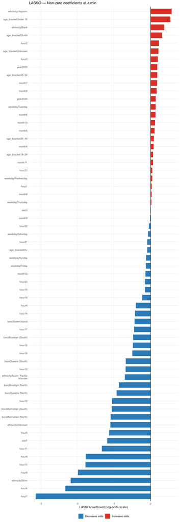

```r
coef_min %>%
  mutate(
    direction = ifelse(estimate > 0, "Increases odds", "Decreases odds"),
    feature   = stringr::str_wrap(feature, 30)
  ) %>%
  ggplot(aes(x = estimate, y = reorder(feature, estimate), fill = direction)) +
  geom_col(width = 0.7) +
  geom_vline(xintercept = 0, linewidth = 0.4) +
  scale_fill_manual(values = c("Increases odds" = "#d73027", "Decreases odds" = "#2c7bb6")) +
  labs(
    x     = "LASSO coefficient (log-odds scale)",
    y     = NULL,
    fill  = NULL,
    title = "LASSO — Non-zero coefficients at λ.min"
  ) +
  theme_minimal(base_size = 10) +
  theme(legend.position = "bottom", panel.grid.minor = element_blank())
```

#### 5.3.2.1) General Interpretation

At $\lambda_{\text{min}}$, LASSO retains 62 non-zero coefficients. The coefficient is on the log-odds scale:

$$\log\left(\frac{P(\text{arrested}=1)}{1-P(\text{arrested}=1)}\right) =
\beta_0+\sum_j\beta_jX_j$$

The corresponding odds ratio is

$$OR_j=e^{\beta_j}$$

Therefore:

- $\beta_j > 0$, $OR > 1$: higher estimated odds of `arrested = 1`.
- $\beta_j < 0$, $OR < 1$: lower estimated odds.
- $\beta_j \approx 0$, $OR \approx 1$: relatively little contribution after regularisation.

Note that, for categorical variables, each coefficient is relative to the omitted reference category.

> These odds ratios are derived from penalised coefficients and should be interpreted as predictive associations originating from the model. In fact, they do not represent unbiased inferential effect estimates.

#### 5.3.2.2) Specific Interpretation

The strongest coefficients are coming from `hour`, `ethnicity`/`sex` and `boro` predictors (in this order).

First of all, for what concerns `hour` we have:

| Feature | Log-odds | OR |
| --- | --- | --- |
| `hour7` | -3.141 | 0.043 |
| `hour6` | -2.329 | 0.097 |
| `hour8` | -1.986 | 0.137 |
| `hour10` | -1.779 | 0.169 |
| `hour9` | -1.772 | 0.170 |
| `hour11` | -1.333 | 0.264 |

*How do we interpret this?* Assuming `hour0` is the reference category, $OR_{\text{hour7}} = 0.043$ means that, **holding the other model variables constant, observations occurring at hour 7 have estimated odds of arrest approximately** $95.7\%$ lower than the reference hour:

$$1-0.043=0.957$$

We underline this **does not mean that the probability of arrest is** $95.7\%$ **lower**. The odds ratio and probability ratio are different quantities.

**Conclusions**:

- The **concentration of large coefficients among the hour variables suggests that time of day is an important component in this model**.
- There is also a **clear pattern** rather than one isolated hour. In fact, hours 5–17 are **predominantly negative relative to the reference**, while the **coefficients become much closer to zero later in the evening**.

Then, some of the larger non-time coefficients are:

- `ethnicityOther`: $OR = 0.113$
- `ethnicityUnknown`: $OR = 0.333$
- `ethnicityAsian / Pacific Islander`: $OR = 0.495$
- `ethnicityHispanic`: $OR = 1.776$
- `ethnicityBlack`: $OR = 1.452$
- `sexF`: $OR = 0.306$

These should be interpreted only relative to the reference categories `ethnicityWhite` and `sexM`.

*How do we interpret this?* `ethnicityBlack` has an estimated odds ratio of $1.452$, meaning approximately $45.2\%$ higher estimated odds of arrest relative to that reference category (`ethnicityWhite`), conditional on the other variables.

While it is surely incorrect to say that people who self-reported their ethnicity as black are subject to a higher probability of arrest, we can say that they are “associated with higher predicted odds” of arrest (w.r.t the reference category).

Finally, several borough coefficients are relatively large:

- `boroManhattan (North)`: $OR = 0.335$
- `boroManhattan (South)`: $OR = 0.347$
- `boroQueens (North)`: $OR = 0.395$
- `boroBrooklyn (North)`: $OR = 0.420$

The fact that several geographic categories receive quite large coefficients **suggests that where the vehicle stop occurs contains substantial predictive information about whether an arrest is recorded**.

### 5.3.3) Non-Zero Coefficients ats λ.1se

If the same major predictors remain at $\lambda_{\text{1se}}$, while mostly small coefficients disappear, that would provide strong evidence that our main predictive relationships are robust to regularisation.

```r
coef_1se %>%
  kbl(
    caption   = "LASSO coefficients at λ.1se (sorted by |estimate|)",
    col.names = c("Feature", "Log-odds", "Odds Ratio")
  ) %>%
  kable_styling(bootstrap_options = c("striped", "condensed"), full_width = FALSE)
```

LASSO coefficients at λ.1se (sorted by |estimate|)

| Feature | Log-odds | Odds Ratio |
| --- | --- | --- |
| hour7 | -1.9603 | 0.141 |
| hour8 | -1.4526 | 0.234 |
| hour6 | -1.4292 | 0.239 |
| ethnicityOther | -1.3808 | 0.251 |
| hour10 | -1.3409 | 0.262 |
| hour9 | -1.3249 | 0.266 |
| boroManhattan (North) | -0.9792 | 0.376 |
| sexF | -0.9757 | 0.377 |
| hour11 | -0.9679 | 0.380 |
| boroManhattan (South) | -0.9480 | 0.388 |
| ethnicityUnknown | -0.9444 | 0.389 |
| boroQueens (North) | -0.8143 | 0.443 |
| boroBrooklyn (North) | -0.7424 | 0.476 |
| hour12 | -0.7242 | 0.485 |
| ethnicityAsian / Pacific Islander | -0.6131 | 0.542 |
| ethnicityHispanic | 0.5764 | 1.780 |
| hour5 | -0.5694 | 0.566 |
| boroQueens (South) | -0.5597 | 0.571 |
| age_bracketUnder 18 | 0.4570 | 1.579 |
| hour13 | -0.3882 | 0.678 |
| ethnicityBlack | 0.3875 | 1.473 |
| boroBrooklyn (South) | -0.3688 | 0.692 |
| hour2 | 0.3673 | 1.444 |
| hour3 | 0.3133 | 1.368 |
| hour23 | 0.2342 | 1.264 |
| hour16 | -0.2218 | 0.801 |
| boroStaten Island | -0.2120 | 0.809 |
| hour15 | -0.1941 | 0.824 |
| hour1 | 0.1899 | 1.209 |
| hour17 | -0.1752 | 0.839 |
| age_bracket55–64 | 0.1730 | 1.189 |
| month12 | -0.1629 | 0.850 |
| hour14 | -0.1416 | 0.868 |
| age_bracketUnknown | 0.1372 | 1.147 |
| hour22 | 0.1360 | 1.146 |
| weekdayTuesday | 0.1048 | 1.111 |
| hour21 | 0.1008 | 1.106 |
| year2025 | 0.0870 | 1.091 |
| month7 | 0.0834 | 1.087 |
| weekdayFriday | -0.0772 | 0.926 |
| weekdaySunday | -0.0656 | 0.936 |
| month9 | 0.0635 | 1.066 |
| age_bracket45–54 | 0.0600 | 1.062 |
| month3 | -0.0478 | 0.953 |
| hour19 | 0.0423 | 1.043 |
| hour20 | 0.0408 | 1.042 |
| year2024 | 0.0399 | 1.041 |
| month6 | 0.0273 | 1.028 |
| weekdayWednesday | 0.0132 | 1.013 |
| month10 | 0.0105 | 1.011 |
| weekdaySaturday | -0.0042 | 0.996 |
| hour4 | -0.0020 | 0.998 |
| age_bracket18–24 | 0.0012 | 1.001 |

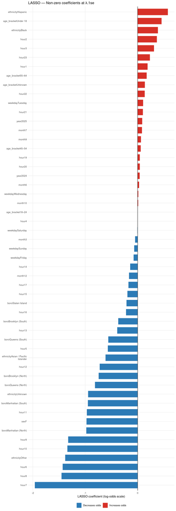

```r
coef_1se %>%
  mutate(
    direction = ifelse(estimate > 0, "Increases odds", "Decreases odds"),
    feature   = stringr::str_wrap(feature, 30)
  ) %>%
  ggplot(aes(x = estimate, y = reorder(feature, estimate), fill = direction)) +
  geom_col(width = 0.7) +
  geom_vline(xintercept = 0, linewidth = 0.4) +
  scale_fill_manual(values = c("Increases odds" = "#d73027", "Decreases odds" = "#2c7bb6")) +
  labs(
    x     = "LASSO coefficient (log-odds scale)",
    y     = NULL,
    fill  = NULL,
    title = "LASSO — Non-zero coefficients at λ.1se"
  ) +
  theme_minimal(base_size = 10) +
  theme(legend.position = "bottom", panel.grid.minor = element_blank())
```

#### 5.3.3.1) The strongest effects are largely preserved

This comparison is quite informative:

- At $\lambda_{\text{min}}$, our strongest coefficient is $\text{hour7} = -3.14, \,\, \text{OR} = 0.043$
- At $\lambda_{\text{1se}}$ we have $\text{hour7} = -1.96, \,\, \text{OR} = 0.141$

So the **coefficient is substantially shrunk toward zero** (as LASSO is designed to do) but it **remains one of the strongest predictors**.

The same happens for the other important hour variables:

| Feature | OR $\lambda_{\text{min}}$ | OR $\lambda_{\text{1se}}$ |
| --- | --- | --- |
| `hour7` | 0.043 | 0.141 |
| `hour8` | 0.137 | 0.234 |
| `hour6` | 0.097 | 0.239 |
| `hour10` | 0.169 | 0.262 |
| `hour9` | 0.170 | 0.266 |
| `hour11` | 0.264 | 0.380 |

Therefore, the **ranking and direction are remarkably stable**.

#### 5.3.3.2) The same happens for geography and demographics

Several variables remain strong under more regularisation:

- `boroManhattan (North)`
- `boroManhattan (South)`
- `boroQueens (North)`
- `boroBrooklyn (North)`
- `sexF`
- `ethnicityOther`
- `ethnicityUnknown`
- `ethnicityAsian / Pacific Islander`
- `ethnicityHispanic`
- `ethnicityBlack`
- `age_bracketUnder 18`

For example:

- $\text{OR}_{\text{Black}}: 1.452 \rightarrow 1.473$
- $\text{OR}_{\text{Hispanic}}: 1.776 \rightarrow 1.780$

Interestingly, these two coefficients are **almost unchanged**, despite the much larger $\lambda$.

That suggests their **predictive contribution is sufficiently strong that LASSO continues to retain them under stronger regularisation**.

#### 5.3.3.3) The weaker coefficients are heavily shrunk

This is perhaps the most interesting part of the comparison

At $\lambda_{\text{min}}$, we have several coefficients close to zero:

$$\begin{aligned}
\text{sexU} &: -0.0088\\
\text{weekdayThursday} &: 0.0201\\
\text{month8} &: 0.0268\\
\text{hour1} &: 0.0321\\
\text{weekdayWednesday} &: 0.0428
\end{aligned}$$

At $\lambda_{\text{1se}}$, these become even closer to zero:

$$\begin{aligned}
\text{age 18--24} &: 0.0012\\
\text{hour4} &: -0.0020\\
\text{weekdaySaturday} &: -0.0042\\
\text{month10} &: 0.0105\\
\text{weekdayWednesday} &: 0.0132
\end{aligned}$$

These variables are contributing very little to the linear predictor after regularisation.

This is exactly the expected behaviour from LASSO: **stronger regularisation sets weak dummy coefficients to zero while preserving the variables that carry more signal**.

#### 5.3.3.4) Final remarks on `hour`

As we said above, the hour coefficients are not simply “important” individually, rather they form a **structured temporal pattern**. In fact, relative to the reference hour:

- hours 2–3 have positive coefficients;
- hours 5–13 are mainly negative;
- hours 14–22 are mostly weakly negative or close to zero;
- hour 23 is positive.

This suggests that **time of day is an important predictor of arrest probability**, rather than one particular hour being responsible for the model’s performance. However, because we encoded `hour` as a categorical variable, the model estimates each hour independently relative to the reference hour. It does **not** assume a smooth temporal relationship.

## 5.4) Evaluation on Test Set

```r
prob_lasso_min_train <- as.numeric(predict(cv_lasso, newx = X_train, s = "lambda.min", type = "response"))
prob_lasso_1se_train <- as.numeric(predict(cv_lasso, newx = X_train, s = "lambda.1se", type = "response"))

roc_lasso_min_train <- pROC::roc(y_train, prob_lasso_min_train, quiet = TRUE)
roc_lasso_1se_train <- pROC::roc(y_train, prob_lasso_1se_train, quiet = TRUE)

thr_lasso_min <- best_thresh(roc_lasso_min_train)
thr_lasso_1se <- best_thresh(roc_lasso_1se_train)


prob_lasso_min <- as.numeric(predict(cv_lasso, newx = X_test, s = "lambda.min", type = "response"))
prob_lasso_1se <- as.numeric(predict(cv_lasso, newx = X_test, s = "lambda.1se", type = "response"))

roc_lasso_min <- pROC::roc(y_test, prob_lasso_min, quiet = TRUE)
roc_lasso_1se <- pROC::roc(y_test, prob_lasso_1se, quiet = TRUE)

auc_lasso_min <- as.numeric(pROC::auc(roc_lasso_min))
auc_lasso_1se <- as.numeric(pROC::auc(roc_lasso_1se))

class_lasso_min <- as.integer(prob_lasso_min >= thr_lasso_min)
met_lasso_min   <- class_metrics(y_test, class_lasso_min)

class_lasso_1se <- as.integer(prob_lasso_1se >= thr_lasso_1se)
met_lasso_1se   <- class_metrics(y_test, class_lasso_1se)
```

### 5.4.1) Confusion Matrix

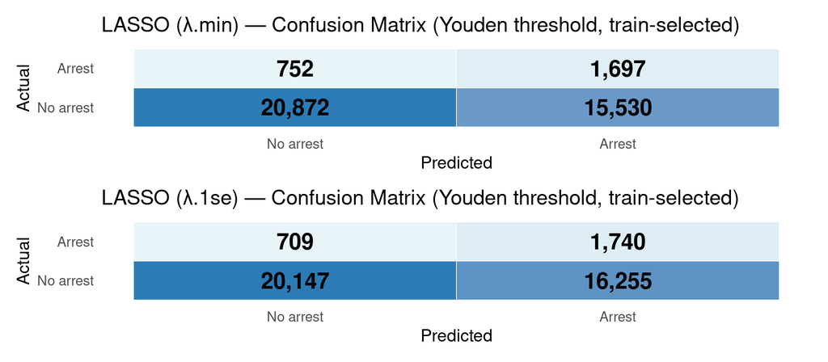

```r
p_cm_min <- plot_cm(y_test, class_lasso_min, "LASSO (λ.min) — Confusion Matrix (Youden threshold, train-selected)")
p_cm_1se <- plot_cm(y_test, class_lasso_1se, "LASSO (λ.1se) — Confusion Matrix (Youden threshold, train-selected)")

p_cm_min / p_cm_1se
```

```r
cat(sprintf(
  "λ.min — AUC: %.4f  |  Threshold (Youden, train-selected): %.4f  |  Sens: %.3f  |  Spec: %.3f  |  Bal.Acc: %.3f\n",
  auc_lasso_min, thr_lasso_min,
  met_lasso_min$sensitivity, met_lasso_min$specificity, met_lasso_min$balanced_acc
))
```

```
## λ.min — AUC: 0.6869  |  Threshold (Youden, train-selected): 0.0494  |  Sens: 0.693  |  Spec: 0.573  |  Bal.Acc: 0.633
```

```r
cat(sprintf(
  "λ.1se — AUC: %.4f  |  Threshold (Youden, train-selected): %.4f  |  Sens: %.3f  |  Spec: %.3f  |  Bal.Acc: %.3f\n",
  auc_lasso_1se, thr_lasso_1se,
  met_lasso_1se$sensitivity, met_lasso_1se$specificity, met_lasso_1se$balanced_acc
))
```

```
## λ.1se — AUC: 0.6866  |  Threshold (Youden, train-selected): 0.0501  |  Sens: 0.710  |  Spec: 0.553  |  Bal.Acc: 0.632
```

The confusion matrices reveal an important point that the CV-AUC alone does not: **the two LASSO models have very similar discrimination, but their classification behaviour at the chosen threshold is different.**

The confusion matrices contain the following counts (rows are actual classes and columns are predicted classes):

| Cell | $\lambda_{\min}$ | $\lambda_{1se}$ |
| --- | --- | --- |
| TP | 1,697 | 1,740 |
| FN | 752 | 709 |
| TN | 20,872 | 20,147 |
| FP | 15,530 | 16,255 |

Each matrix contains 38,851 test observations, including 2,449 actual arrests and 36,402 actual non-arrests. Accuracy is not the primary measure here because the target is strongly imbalanced.

| Metric | $\lambda_{\text{min}}$ | $\lambda_{\text{1se}}$ |
| --- | --- | --- |
| Accuracy | **0.581** | **0.563** |
| Sensitivity / Recall | **0.693** | **0.710** |
| Specificity | **0.573** | **0.553** |
| Precision | **0.099** | **0.097** |
| F1 | **0.172** | **0.170** |
| Balanced Accuracy | **0.633** | **0.632** |

#### 5.4.1.1) Recall improves with λ.1se

The 1-SE model identifies more of the actual arrests:

- $69.3\% \rightarrow 71.0\%$
- In absolute terms, $1,740 - 1,697 = \mathbf{43}$ additional arrests are correctly identified.

Correspondingly, false negatives decrease $752 \rightarrow 709$.

So the stronger regularisation model is actually **better at detecting the minority class at this particular classification threshold**.

#### 5.4.1.2) But λ.1se does this by producing more false positives

False positives increase from $15,530 \rightarrow 16,255$, that is $725$ **additional non-arrests incorrectly classified as arrests**.

Consequently, specificity decreases $57.3\% \rightarrow 55.3\%$, and precision decreases slightly from $9.9\%$ to $9.7\%$.

So $\lambda_{\text{1se}}$ is effectively more willing to say **“arrest”**, resulting in:

- $\uparrow \textbf{Recall}$
- But $\downarrow \textbf{Specficity} \, \text{and} \, \textbf{Precision}$

#### 5.4.1.3) Main result comes from the F1 and balanced accuracy

Despite the different confusion matrices, we focus on more important metrics:

$$F1_{\text{min}} = 0.172 \quad \text{vs}
\quad F1_{1se}=0.170$$
And balanced accuracy is almost identical:

$$(\text{min}) \, 0.633 \quad \text{vs}
\quad (\text{1se}) \, 0.632$$

So from the perspective of **balancing performance between the two classes**, the two models are essentially indistinguishable at this threshold.

#### 5.4.1.4) However, the precision is the real weakness

This is probably the most important performance limitation of the model:

- For $\lambda_{\text{min}}$, $Precision = \frac{1697}{1697+15530} = \mathbf{9.9\%}$.
- For $\lambda_{\text{1se}}$, $Precision = \frac{1740}{1740+16255} = \mathbf{9.7\%}$.

The low precision is not surprising given the class imbalance and the large number of false positives. This is due to the fact it is particularly sensitive to the number of false positives.

#### 5.4.1.5) Final Comparison

The overall picture is:

| $\lambda_{\text{min}}$ | $\lambda_{\text{1se}}$ |
| --- | --- |
| More complex model | Simpler model (9 less coefficients) |
| Slightly higher CV-AUC: **0.7394** | Nearly identical CV-AUC: **0.7373** |
| Lower sensitivity | **Higher sensitivity** |
| **Higher specificity** | Lower specificity |
| **Higher precision** | Slightly lower precision |
| Slightly higher F1 | Slightly lower F1 |
| Virtually identical balanced accuracy | Virtually identical balanced accuracy |

Conclusion: **The stronger-regularised model achieves almost identical discrimination and balanced classification performance while using fewer coefficients and identifying a slightly larger proportion of actual arrests.**

Questions we can answer:

- *Can the model discriminate?* Reasonable discrimination, but far from perfect.
- *What happens when we use a particular threshold to classify arrests?* Both models have low precision ($\approx 9.7-9.9\%$), despite sensitivity around $69-71\%$.

### 5.4.2) Performance Analysis

This was partly covered in the previous section, so here we will be focusing on the metrics that we have yet to mention.

```r
bind_rows(
  compute_metrics(y_test, prob_lasso_min, thr_lasso_min, "LASSO λ.min"),
  compute_metrics(y_test, prob_lasso_1se, thr_lasso_1se, "LASSO λ.1se")
) %>%
  kbl(
    caption = "LASSO — full evaluation metrics (test set; Youden threshold selected on training set)",
    col.names = c(
      "Model","AUC","PR-AUC","Log-Loss","Brier", "Threshold","Sensitivity",
      "Specificity","Precision","F1","MCC","Bal. Acc."
    )
  ) %>%
  kable_styling(
    bootstrap_options = c("striped","condensed"),
    full_width = TRUE
  )
```

LASSO — full evaluation metrics (test set; Youden threshold selected on training set)

| Model | AUC | PR-AUC | Log-Loss | Brier | Threshold | Sensitivity | Specificity | Precision | F1 | MCC | Bal. Acc. |
| --- | --- | --- | --- | --- | --- | --- | --- | --- | --- | --- | --- |
| LASSO λ.min | 0.6869 | 0.1207 | 0.2254 | 0.0576 | 0.0494 | 0.693 | 0.573 | 0.099 | 0.172 | 0.130 | 0.633 |
| LASSO λ.1se | 0.6866 | 0.1203 | 0.2238 | 0.0576 | 0.0501 | 0.710 | 0.553 | 0.097 | 0.170 | 0.129 | 0.632 |

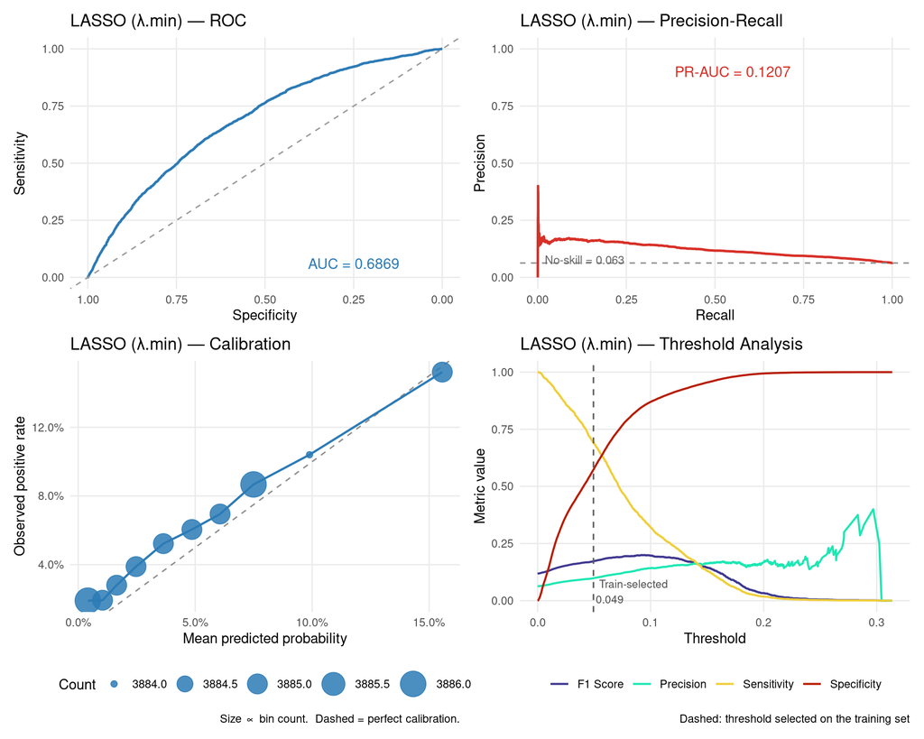

```r
eval_quad_plot(y_test, prob_lasso_min, thr_lasso_min, "LASSO (λ.min)")
```

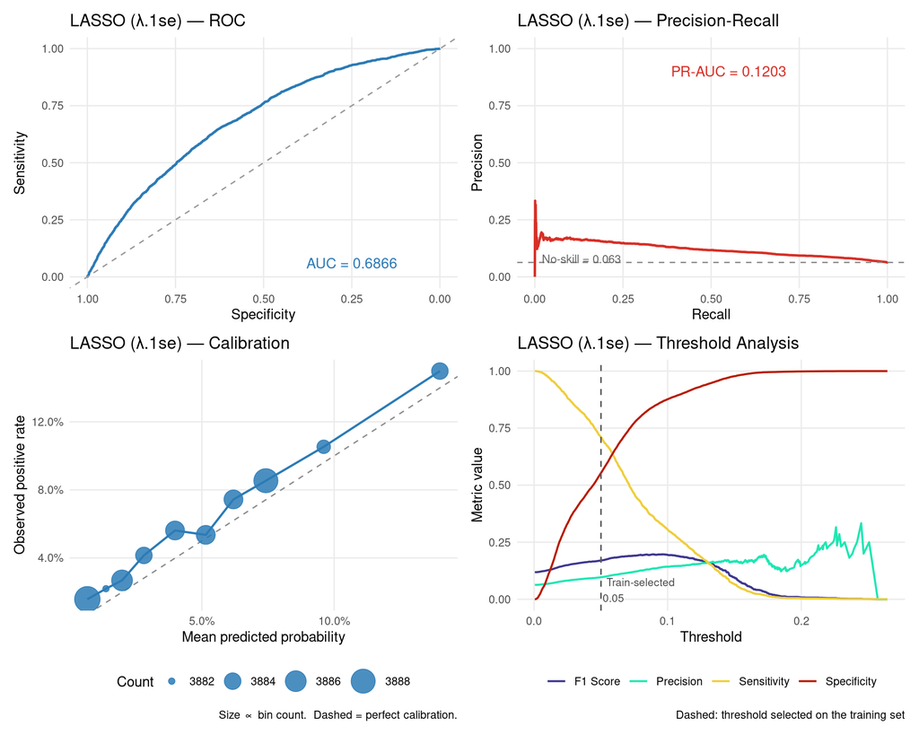

```r
eval_quad_plot(y_test, prob_lasso_1se, thr_lasso_1se, "LASSO (λ.1se)")
```

#### 5.4.2.1) Overall performance

| Metric | $\lambda_{\min}$ | $\lambda_{1se}$ | Interpretation |
| --- | --- | --- | --- |
| **AUC** | 0.6869 | 0.6866 | Similar discrimination |
| **PR-AUC** | 0.1207 | 0.1203 | Similar minority-class performance |
| **Log-Loss** | 0.2254 | **0.2238** | Slightly better probability estimates for 1-SE |
| **Brier** | 0.0576 | 0.0576 | Essentially identical probability accuracy |
| Threshold | 0.0494 | 0.0501 | Both low cutoffs, selected on the training set via Youden’s criterion and then applied unchanged to the test set |
| **Sensitivity** | 0.693 | 0.710 | $\lambda_{1se}$ detects more actual arrests |
| **Specificity** | 0.573 | 0.553 | $\lambda_{\min}$ rejects more non-arrests correctly |
| **Precision** | 0.099 | 0.097 | Low for both models |
| **F1** | 0.172 | 0.170 | Similar and mainly constrained by low precision |
| **MCC** | 0.130 | 0.129 | Weak overall association |
| **Balanced Accuracy** | 0.633 | 0.632 | Essentially identical |

The main conclusion is very consistent with what we have already seen: **The two LASSO models have almost indistinguishable predictive performance on the test set. The 1-SE model achieves this with fewer coefficients, making it the more parsimonious choice.**

#### 5.4.2.2) AUC

The test-set AUC is $\approx 0.687$.

This means that if we randomly select (i) one observation where an arrest occurred, and (ii) one observation where an arrest did not occur, the model assigns a higher predicted probability to the arrest observation about **69% of the time**.

> Note: This is a measure of **discrimination**, independent of a particular classification threshold.

The important point is that

$$\text{AUC}_{\text{CV}} = 0.739 \quad
\text{vs} \quad \text{AUC}_{\text{test}} = 0.687$$

So there is a modest reduction in discrimination on the held-out test set, but both models remain essentially identical and only modestly better than random.

However, the choice between either lambda has **virtually no effect on test-set discrimination**.

#### 5.4.2.3) PR-AUC

This is particularly important given our imbalanced outcome.

Our positive class is rare, so ROC-AUC can sometimes give an overly optimistic impression of performance. **Precision-Recall AUC focuses directly on the positive class**, considering the trade-off between precision and recall.

Here, we obtain:

$$\text{PR} \text{-}
\text{AUC}_{\text{min}} = 0.1207 \quad \text{vs} \quad \text{PR}
\text{-} \text{AUC}_{\text{1se}} = 0.1203$$
Again, essentially identical.

*But how good is 0.12?* This needs to be interpreted relative to the prevalence of the positive class.

- From our confusion matrix, the test-set arrest prevalence is approximately $\frac{2449}{38851} \approx 0.063$
- So, for a random classifier, the expected (minimum) PR-AUC is approximately the positive prevalence $\text{PR} \text{-} \text{AUC}_{\text{baseline}} \approx 0.063$
- And, our model achieves $0.121$

So the PR-AUC is roughly **1.9 times the prevalence baseline**. Both models extract meaningful information about the rare positive class, but the absolute precision-recall performance remains low and the difference between them is negligible.

#### 5.4.2.4) Log-Loss

> Log-loss evaluates the **quality of the predicted probabilities**, rather than simply stating whether the final classification is correct.

This measure cares about **how confident the model is**. For example, predicting $p=0.51$ for an actual arrest is not treated the same as predicting $p=0.99$. In fact, a highly confident incorrect prediction receives a strong penalty.

In our case:

$$\text{(min)} \, 0.2254 \quad \text{vs}
\quad \text{(1se)} \, 0.2238$$

So $\lambda_{\text{1se}}$ has a slightly lower log-loss, although the difference is small. The two models therefore have **essentially equivalent probabilistic performance**, and the calibration plots should not be interpreted as perfect.

#### 5.4.2.5) Brier Score

The Brier score is useful here because it evaluates whether the predicted probabilities are close to the observed outcomes, rather than merely whether the model ranks observations correctly.

> Formally, the Brier score measures the squared error of the predicted probabilities (the lower, the better).

We get $0.0576$ for **both models**, meaning that (according to Brier score) there is effectively **no difference whatsoever** between the two LASSO specifications.

Furthermore, a model that simply predicted the prevalence $p \approx 0.063$ (for everyone) would have a Brier score approximately $p (1-p) \approx 0.063 (0.937) \approx 0.059$. Our model reaches $0.0576$, which is a modest improve over the baseline.

Here, we just re-confirm that **the models contain predictive information, but the probability predictions are not exceptionally accurate.**

#### 5.4.2.6) MCC

The **Matthews Correlation Coefficient (MCC)** is particularly useful for imbalanced classification because it incorporates all four components of the confusion matrix:

$$MCC = \frac{TP\cdot TN-FP\cdot
FN}{\sqrt{(TP+FP)(TP+FN)(TN+FP)(TN+FN)}} \in [-1, 1]$$
Where,

- $1$ = perfect prediction
- $0$ = no better than random association
- $-1$ = completely incorrect prediction

Our results are:

$$\text{MCC}_{\text{min}} = 0.130 \quad
\text{vs} \quad \text{MCC}_{\text{1se}} = 0.129$$

Thus, there is a **positive but weak association between predictions and actual outcomes**. Simply put:

- The model is doing meaningfully better than random classification;
- But that its classification performance is limited.

#### 5.4.2.7) Thresholds

Using Youden’s criterion, the selected thresholds are:

$$\text{(min)} \, 0.0494 \quad \text{vs}
\quad \text{(1se)} \, 0.0501$$

Each threshold is selected once by maximising Youden’s $J$ on the corresponding lambda’s training-set ROC curve, then frozen and applied unchanged to the test set, so no test-set information is used in choosing the cutoff.

These are very low compared with the conventional $0.5$ threshold, reflecting the rarity of the positive class. The low cutoffs favor sensitivity and inevitably generate many false positives (see the Confusion Matrix for the trade-off).

Therefore, the difference between the two LASSO models is not being driven by radically different classification thresholds.

#### 5.4.2.8) Final Remarks

Let us up the metrics together:

- **Discrimination**, $\text{AUC}=0.6869$ and $0.6866$: Both models have **modest ability to distinguish arrests from non-arrests**, with practically identical ROC performance.
- **Rare-class performance**, $\text{PR} \text{-} \text{AUC}=0.1207$ and $0.1203$: Both models perform clearly above the prevalence baseline of approximately $0.063$, but precision remains low because arrests are relatively rare.
- **Probability predictions**, $\text{Brier}=0.0576$ for both models and Log-Loss $=0.2254$ and $0.2238$: $\lambda_{1se}$ has a slightly lower log-loss, while Brier scores are identical and calibration is not perfect.
- **Classification**, $\text{MCC}=0.130$ and $0.129$: The thresholded predictions have only a **weak overall association** with the actual outcome.
- **Class balance**, $\text{ACC}_{\text{Balanced}}=0.633$ and $0.632$: The models have nearly identical balanced performance.

Now for the final conclusions:

- The LASSO models demonstrate **modest discrimination** on the held-out test set (AUC $0.6869$ and $0.6866$) and improve substantially over the positive-class prevalence baseline in terms of PR-AUC.
- However, their threshold-dependent classification performance remains limited, with low precision and MCC values of approximately $0.130$ and $0.129$.
- The Brier score and log-loss also indicate only modest improvement in probabilistic prediction.
- Finally, the models exhibit almost identical test-set performance across these metrics. Therefore, the additional complexity of the $\lambda_{\text{min}}$ model provides little evidence of improved predictive performance, which favors the more parsimonious $\lambda_{\text{1se}}$ model.